# Lab 5: Linear Regression through Gradient Descent

**Aim:** To implement Linear Regression using the Gradient Descent optimization algorithm and evaluate its performance on the Student Performance dataset.

**Dataset:** Student Performance Dataset (UCI Machine Learning Repository)

**Target Variable:** G3 (Final Grade, 0-20)

## 1. Import Libraries

```python
import numpy as np
import pandas as pd
import matplotlib.pyplot as plt
import seaborn as sns
from sklearn.model_selection import train_test_split
from sklearn.preprocessing import StandardScaler, LabelEncoder
from sklearn.metrics import mean_absolute_error, mean_squared_error, r2_score
import warnings
warnings.filterwarnings('ignore')

print("All libraries imported successfully.")
```

```
All libraries imported successfully.
```

## 2. Load the Dataset

```python
# Load the Math course student performance dataset
df = pd.read_csv('student/student-mat.csv', sep=';')

print(f"Dataset shape: {df.shape}")
print(f"Number of samples: {df.shape[0]}")
print(f"Number of features: {df.shape[1]}")
df.head()
```

```
Dataset shape: (395, 33)
Number of samples: 395
Number of features: 33
```

|  | school | sex | age | address | famsize | Pstatus | Medu | Fedu | Mjob | Fjob | ... | famrel | freetime | goout | Dalc | Walc | health | absences | G1 | G2 | G3 |
| --- | --- | --- | --- | --- | --- | --- | --- | --- | --- | --- | --- | --- | --- | --- | --- | --- | --- | --- | --- | --- | --- |
| 0 | GP | F | 18 | U | GT3 | A | 4 | 4 | at_home | teacher | ... | 4 | 3 | 4 | 1 | 1 | 3 | 6 | 5 | 6 | 6 |
| 1 | GP | F | 17 | U | GT3 | T | 1 | 1 | at_home | other | ... | 5 | 3 | 3 | 1 | 1 | 3 | 4 | 5 | 5 | 6 |
| 2 | GP | F | 15 | U | LE3 | T | 1 | 1 | at_home | other | ... | 4 | 3 | 2 | 2 | 3 | 3 | 10 | 7 | 8 | 10 |
| 3 | GP | F | 15 | U | GT3 | T | 4 | 2 | health | services | ... | 3 | 2 | 2 | 1 | 1 | 5 | 2 | 15 | 14 | 15 |
| 4 | GP | F | 16 | U | GT3 | T | 3 | 3 | other | other | ... | 4 | 3 | 2 | 1 | 2 | 5 | 4 | 6 | 10 | 10 |

5 rows × 33 columns

## 3. Exploratory Data Analysis

```python
# Basic information about the dataset
print("=" * 50)
print("DATASET INFO")
print("=" * 50)
df.info()

print("\n" + "=" * 50)
print("STATISTICAL SUMMARY")
print("=" * 50)
df.describe()
```

```
==================================================
DATASET INFO
==================================================
<class 'pandas.core.frame.DataFrame'>
RangeIndex: 395 entries, 0 to 394
Data columns (total 33 columns):
 #   Column      Non-Null Count  Dtype
---  ------      --------------  -----
 0   school      395 non-null    object
 1   sex         395 non-null    object
 2   age         395 non-null    int64
 3   address     395 non-null    object
 4   famsize     395 non-null    object
 5   Pstatus     395 non-null    object
 6   Medu        395 non-null    int64
```

[output cut: 32 more lines]

|  | age | Medu | Fedu | traveltime | studytime | failures | famrel | freetime | goout | Dalc | Walc | health | absences | G1 | G2 | G3 |
| --- | --- | --- | --- | --- | --- | --- | --- | --- | --- | --- | --- | --- | --- | --- | --- | --- |
| count | 395.000000 | 395.000000 | 395.000000 | 395.000000 | 395.000000 | 395.000000 | 395.000000 | 395.000000 | 395.000000 | 395.000000 | 395.000000 | 395.000000 | 395.000000 | 395.000000 | 395.000000 | 395.000000 |
| mean | 16.696203 | 2.749367 | 2.521519 | 1.448101 | 2.035443 | 0.334177 | 3.944304 | 3.235443 | 3.108861 | 1.481013 | 2.291139 | 3.554430 | 5.708861 | 10.908861 | 10.713924 | 10.415190 |
| std | 1.276043 | 1.094735 | 1.088201 | 0.697505 | 0.839240 | 0.743651 | 0.896659 | 0.998862 | 1.113278 | 0.890741 | 1.287897 | 1.390303 | 8.003096 | 3.319195 | 3.761505 | 4.581443 |
| min | 15.000000 | 0.000000 | 0.000000 | 1.000000 | 1.000000 | 0.000000 | 1.000000 | 1.000000 | 1.000000 | 1.000000 | 1.000000 | 1.000000 | 0.000000 | 3.000000 | 0.000000 | 0.000000 |
| 25% | 16.000000 | 2.000000 | 2.000000 | 1.000000 | 1.000000 | 0.000000 | 4.000000 | 3.000000 | 2.000000 | 1.000000 | 1.000000 | 3.000000 | 0.000000 | 8.000000 | 9.000000 | 8.000000 |
| 50% | 17.000000 | 3.000000 | 2.000000 | 1.000000 | 2.000000 | 0.000000 | 4.000000 | 3.000000 | 3.000000 | 1.000000 | 2.000000 | 4.000000 | 4.000000 | 11.000000 | 11.000000 | 11.000000 |
| 75% | 18.000000 | 4.000000 | 3.000000 | 2.000000 | 2.000000 | 0.000000 | 5.000000 | 4.000000 | 4.000000 | 2.000000 | 3.000000 | 5.000000 | 8.000000 | 13.000000 | 13.000000 | 14.000000 |
| max | 22.000000 | 4.000000 | 4.000000 | 4.000000 | 4.000000 | 3.000000 | 5.000000 | 5.000000 | 5.000000 | 5.000000 | 5.000000 | 5.000000 | 75.000000 | 19.000000 | 19.000000 | 20.000000 |

```python
# Check for missing values
print("Missing values per column:")
missing = df.isnull().sum()
print(missing[missing > 0] if missing.sum() > 0 else "No missing values found.")
print(f"\nTotal missing values: {df.isnull().sum().sum()}")
```

```
Missing values per column:
No missing values found.

Total missing values: 0
```

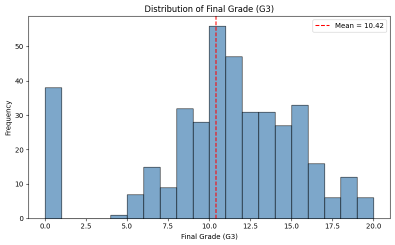

```python
# Distribution of the target variable (G3 - Final Grade)
plt.figure(figsize=(8, 5))
plt.hist(df['G3'], bins=20, edgecolor='black', color='steelblue', alpha=0.7)
plt.xlabel('Final Grade (G3)')
plt.ylabel('Frequency')
plt.title('Distribution of Final Grade (G3)')
plt.axvline(df['G3'].mean(), color='red', linestyle='--', label=f"Mean = {df['G3'].mean():.2f}")
plt.legend()
plt.tight_layout()
plt.show()
```

```python
# Identify categorical and numerical columns
categorical_cols = df.select_dtypes(include='object').columns.tolist()
numerical_cols = df.select_dtypes(include=np.number).columns.tolist()

print(f"Categorical columns ({len(categorical_cols)}): {categorical_cols}")
print(f"\nNumerical columns ({len(numerical_cols)}): {numerical_cols}")
```

```
Categorical columns (17): ['school', 'sex', 'address', 'famsize', 'Pstatus', 'Mjob', 'Fjob', 'reason', 'guardian', 'schoolsup', 'famsup', 'paid', 'activities', 'nursery', 'higher', 'internet', 'romantic']

Numerical columns (16): ['age', 'Medu', 'Fedu', 'traveltime', 'studytime', 'failures', 'famrel', 'freetime', 'goout', 'Dalc', 'Walc', 'health', 'absences', 'G1', 'G2', 'G3']
```

## 4. Data Preprocessing

```python
# Encode categorical variables using Label Encoding
df_encoded = df.copy()
label_encoders = {}

for col in categorical_cols:
    le = LabelEncoder()
    df_encoded[col] = le.fit_transform(df_encoded[col])
    label_encoders[col] = le
    print(f"{col}: {dict(zip(le.classes_, le.transform(le.classes_)))}")

print("\nEncoding complete.")
df_encoded.head()
```

```
school: {'GP': np.int64(0), 'MS': np.int64(1)}
sex: {'F': np.int64(0), 'M': np.int64(1)}
address: {'R': np.int64(0), 'U': np.int64(1)}
famsize: {'GT3': np.int64(0), 'LE3': np.int64(1)}
Pstatus: {'A': np.int64(0), 'T': np.int64(1)}
Mjob: {'at_home': np.int64(0), 'health': np.int64(1), 'other': np.int64(2), 'services': np.int64(3), 'teacher': np.int64(4)}
Fjob: {'at_home': np.int64(0), 'health': np.int64(1), 'other': np.int64(2), 'services': np.int64(3), 'teacher': np.int64(4)}
reason: {'course': np.int64(0), 'home': np.int64(1), 'other': np.int64(2), 'reputation': np.int64(3)}
guardian: {'father': np.int64(0), 'mother': np.int64(1), 'other': np.int64(2)}
schoolsup: {'no': np.int64(0), 'yes': np.int64(1)}
famsup: {'no': np.int64(0), 'yes': np.int64(1)}
paid: {'no': np.int64(0), 'yes': np.int64(1)}
activities: {'no': np.int64(0), 'yes': np.int64(1)}
nursery: {'no': np.int64(0), 'yes': np.int64(1)}
higher: {'no': np.int64(0), 'yes': np.int64(1)}
internet: {'no': np.int64(0), 'yes': np.int64(1)}
romantic: {'no': np.int64(0), 'yes': np.int64(1)}

Encoding complete.
```

|  | school | sex | age | address | famsize | Pstatus | Medu | Fedu | Mjob | Fjob | ... | famrel | freetime | goout | Dalc | Walc | health | absences | G1 | G2 | G3 |
| --- | --- | --- | --- | --- | --- | --- | --- | --- | --- | --- | --- | --- | --- | --- | --- | --- | --- | --- | --- | --- | --- |
| 0 | 0 | 0 | 18 | 1 | 0 | 0 | 4 | 4 | 0 | 4 | ... | 4 | 3 | 4 | 1 | 1 | 3 | 6 | 5 | 6 | 6 |
| 1 | 0 | 0 | 17 | 1 | 0 | 1 | 1 | 1 | 0 | 2 | ... | 5 | 3 | 3 | 1 | 1 | 3 | 4 | 5 | 5 | 6 |
| 2 | 0 | 0 | 15 | 1 | 1 | 1 | 1 | 1 | 0 | 2 | ... | 4 | 3 | 2 | 2 | 3 | 3 | 10 | 7 | 8 | 10 |
| 3 | 0 | 0 | 15 | 1 | 0 | 1 | 4 | 2 | 1 | 3 | ... | 3 | 2 | 2 | 1 | 1 | 5 | 2 | 15 | 14 | 15 |
| 4 | 0 | 0 | 16 | 1 | 0 | 1 | 3 | 3 | 2 | 2 | ... | 4 | 3 | 2 | 1 | 2 | 5 | 4 | 6 | 10 | 10 |

5 rows × 33 columns

```
Correlation of features with G3 (Final Grade):
G3            1.000000
G2            0.904868
G1            0.801468
Medu          0.217147
higher        0.182465
Fedu          0.152457
reason        0.121994
address       0.105756
sex           0.103456
Mjob          0.102082
paid          0.101996
internet      0.098483
studytime     0.097820
famsize       0.081407
nursery       0.051568
famrel        0.051363
Fjob          0.042286
absences      0.034247
activities    0.016100
freetime      0.011307
famsup       -0.039157
school       -0.045017
Walc         -0.051939
Dalc         -0.054660
Pstatus      -0.058009
health       -0.061335
guardian     -0.070109
schoolsup    -0.082788
traveltime   -0.117142
romantic     -0.129970
goout        -0.132791
age          -0.161579
failures     -0.360415
Name: G3, dtype: float64
```

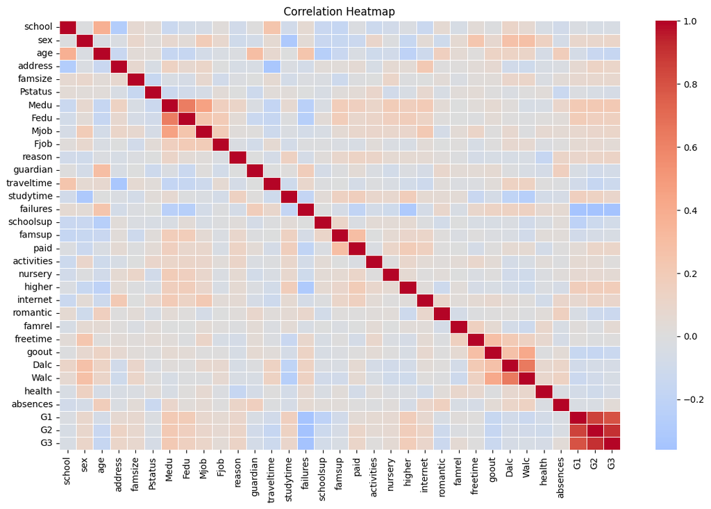

```python
# Correlation heatmap of numerical features with G3
correlation = df_encoded.corr()['G3'].sort_values(ascending=False)
print("Correlation of features with G3 (Final Grade):")
print(correlation)

plt.figure(figsize=(12, 8))
sns.heatmap(df_encoded.corr(), cmap='coolwarm', center=0, linewidths=0.5, fmt='.1f')
plt.title('Correlation Heatmap')
plt.tight_layout()
plt.show()
```

## 5. Feature Selection and Target Variable

```python
# Select input features (X) and target variable (y)
# Drop G1 and G2 (intermediate grades) to avoid data leakage,
# and G3 is the target
X = df_encoded.drop(columns=['G1', 'G2', 'G3'])
y = df_encoded['G3'].values

print(f"Feature matrix shape: {X.shape}")
print(f"Target vector shape: {y.shape}")
print(f"\nSelected features: {X.columns.tolist()}")
```

```
Feature matrix shape: (395, 30)
Target vector shape: (395,)

Selected features: ['school', 'sex', 'age', 'address', 'famsize', 'Pstatus', 'Medu', 'Fedu', 'Mjob', 'Fjob', 'reason', 'guardian', 'traveltime', 'studytime', 'failures', 'schoolsup', 'famsup', 'paid', 'activities', 'nursery', 'higher', 'internet', 'romantic', 'famrel', 'freetime', 'goout', 'Dalc', '…
```

```python
# Feature Scaling using StandardScaler
scaler = StandardScaler()
X_scaled = scaler.fit_transform(X)

print("Feature scaling complete (StandardScaler).")
print(f"Mean of scaled features (should be ~0): {X_scaled.mean(axis=0).round(4)[:5]} ...")
print(f"Std of scaled features (should be ~1):  {X_scaled.std(axis=0).round(4)[:5]} ...")
```

```
Feature scaling complete (StandardScaler).
Mean of scaled features (should be ~0): [-0. -0.  0. -0.  0.] ...
Std of scaled features (should be ~1):  [1. 1. 1. 1. 1.] ...
```

## 6. Train-Test Split

```python
# Split into training (80%) and testing (20%) sets
X_train, X_test, y_train, y_test = train_test_split(
    X_scaled, y, test_size=0.2, random_state=42
)

print(f"Training set size: {X_train.shape[0]}")
print(f"Testing set size:  {X_test.shape[0]}")
```

```
Training set size: 316
Testing set size:  79
```

## 7. Linear Regression using Gradient Descent - Implementation

```python
class LinearRegressionGD:
    """
    Linear Regression using Batch Gradient Descent.

    Hypothesis:  h(x) = X . w + b
    Cost (MSE):  J(w,b) = (1/2m) * sum( (h(xi) - yi)^2 )

    Update rules:
        w = w - alpha * (1/m) * X^T . (h(X) - y)
        b = b - alpha * (1/m) * sum(h(X) - y)
    """

    def __init__(self, learning_rate=0.01, n_iterations=1000):
        self.learning_rate = learning_rate
        self.n_iterations = n_iterations
        self.weights = None
        self.bias = None
        self.cost_history = []

    def fit(self, X, y):
        """Train the model using Gradient Descent."""
        m, n = X.shape  # m = samples, n = features

        # Initialize weights and bias to zeros
        self.weights = np.zeros(n)
        self.bias = 0
        self.cost_history = []

        for i in range(self.n_iterations):
            # Forward pass: compute predictions
            y_pred = X.dot(self.weights) + self.bias

            # Compute error
            error = y_pred - y

            # Compute cost (MSE / 2)
            cost = (1 / (2 * m)) * np.sum(error ** 2)
            self.cost_history.append(cost)

            # Compute gradients
            dw = (1 / m) * X.T.dot(error)
            db = (1 / m) * np.sum(error)

            # Update weights and bias
            self.weights -= self.learning_rate * dw
            self.bias -= self.learning_rate * db

        return self

    def predict(self, X):
        """Make predictions."""
        return X.dot(self.weights) + self.bias

    def get_cost_history(self):
        """Return the cost history during training."""
        return self.cost_history


print("LinearRegressionGD class defined successfully.")
```

```
LinearRegressionGD class defined successfully.
```

## 8. Train the Model

```python
# Train with a chosen learning rate
model = LinearRegressionGD(learning_rate=0.01, n_iterations=1000)
model.fit(X_train, y_train)

print("Model training complete.")
print(f"Final cost: {model.cost_history[-1]:.4f}")
print(f"Bias (intercept): {model.bias:.4f}")
print(f"Number of weights: {len(model.weights)}")
```

```
Model training complete.
Final cost: 7.7213
Bias (intercept): 10.3795
Number of weights: 30
```

## 9. Experiment with Different Learning Rates

```
Learning Rate: 0.0010 | Final Cost: 15.4011
Learning Rate: 0.0100 | Final Cost: 7.7213
Learning Rate: 0.0500 | Final Cost: 7.7210
Learning Rate: 0.1000 | Final Cost: 7.7210
```

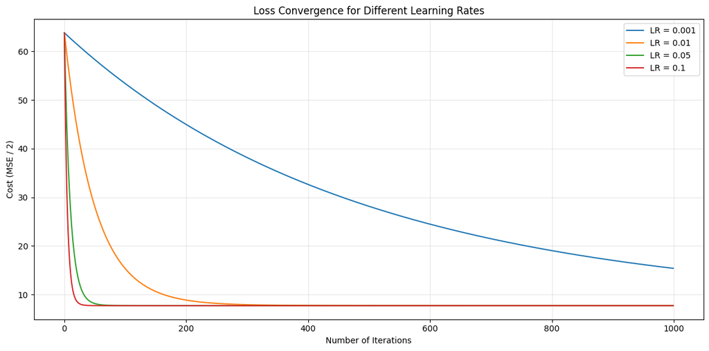

```python
# Experiment with different learning rates
learning_rates = [0.001, 0.01, 0.05, 0.1]
n_iterations = 1000
models = {}

plt.figure(figsize=(12, 6))

for lr in learning_rates:
    lr_model = LinearRegressionGD(learning_rate=lr, n_iterations=n_iterations)
    lr_model.fit(X_train, y_train)
    models[lr] = lr_model

    plt.plot(lr_model.cost_history, label=f'LR = {lr}')
    print(f"Learning Rate: {lr:.4f} | Final Cost: {lr_model.cost_history[-1]:.4f}")

plt.xlabel('Number of Iterations')
plt.ylabel('Cost (MSE / 2)')
plt.title('Loss Convergence for Different Learning Rates')
plt.legend()
plt.grid(True, alpha=0.3)
plt.tight_layout()
plt.show()
```

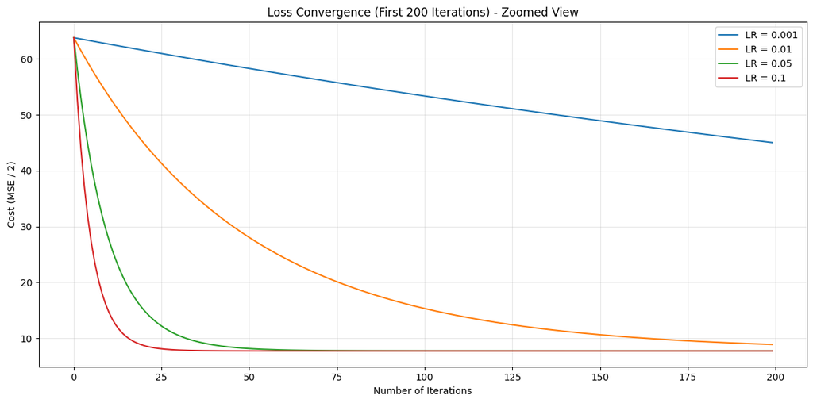

```python
# Zoomed-in view of convergence (first 200 iterations)
plt.figure(figsize=(12, 6))

for lr in learning_rates:
    plt.plot(models[lr].cost_history[:200], label=f'LR = {lr}')

plt.xlabel('Number of Iterations')
plt.ylabel('Cost (MSE / 2)')
plt.title('Loss Convergence (First 200 Iterations) - Zoomed View')
plt.legend()
plt.grid(True, alpha=0.3)
plt.tight_layout()
plt.show()
```

### Observations on Learning Rate

- **LR = 0.001 (too small):** Converges very slowly; the cost is still decreasing at the end of 1000 iterations and has not yet reached the minimum.
- **LR = 0.01 (good):** Converges steadily and reaches a stable minimum within the iterations.
- **LR = 0.05 (fast):** Converges much faster than 0.01 and reaches the minimum in fewer iterations while remaining stable.
- **LR = 0.1 (aggressive):** Converges the fastest and reaches the minimum within very few iterations. For this dataset, it remains stable without oscillation, although larger learning rates can cause oscillation or divergence in general.

## 10. Loss (Cost) vs Iterations Plot

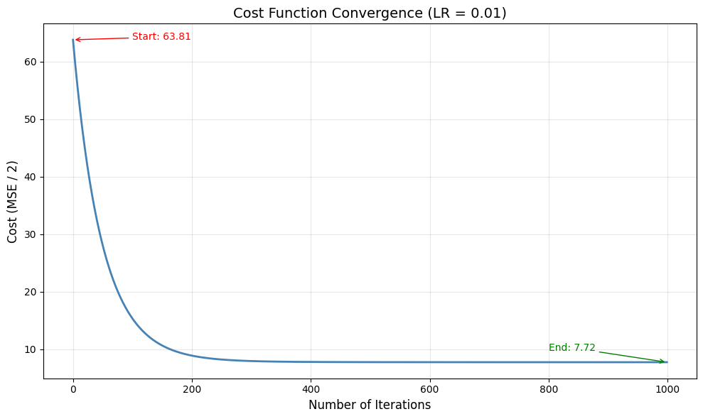

```python
# Detailed cost vs iterations plot for the chosen model (LR = 0.01)
plt.figure(figsize=(10, 6))
plt.plot(model.cost_history, color='steelblue', linewidth=2)
plt.xlabel('Number of Iterations', fontsize=12)
plt.ylabel('Cost (MSE / 2)', fontsize=12)
plt.title('Cost Function Convergence (LR = 0.01)', fontsize=14)
plt.grid(True, alpha=0.3)

# Annotate start and end costs
plt.annotate(f'Start: {model.cost_history[0]:.2f}',
             xy=(0, model.cost_history[0]),
             xytext=(100, model.cost_history[0]),
             arrowprops=dict(arrowstyle='->', color='red'),
             fontsize=10, color='red')

plt.annotate(f'End: {model.cost_history[-1]:.2f}',
             xy=(len(model.cost_history)-1, model.cost_history[-1]),
             xytext=(len(model.cost_history)-200, model.cost_history[-1]+2),
             arrowprops=dict(arrowstyle='->', color='green'),
             fontsize=10, color='green')

plt.tight_layout()
plt.show()
```

## 11. Model Evaluation

```python
# Predictions on the test set
y_pred = model.predict(X_test)

# Calculate evaluation metrics
mae  = mean_absolute_error(y_test, y_pred)
mse  = mean_squared_error(y_test, y_pred)
rmse = np.sqrt(mse)
r2   = r2_score(y_test, y_pred)

print("=" * 45)
print("     MODEL EVALUATION METRICS")
print("=" * 45)
print(f"  Mean Absolute Error  (MAE)  : {mae:.4f}")
print(f"  Mean Squared Error   (MSE)  : {mse:.4f}")
print(f"  Root Mean Squared Error(RMSE): {rmse:.4f}")
print(f"  R-squared Score             : {r2:.4f}")
print("=" * 45)
```

```
=============================================
     MODEL EVALUATION METRICS
=============================================
  Mean Absolute Error  (MAE)  : 3.4959
  Mean Squared Error   (MSE)  : 18.5409
  Root Mean Squared Error(RMSE): 4.3059
  R-squared Score             : 0.0958
=============================================
```

### Interpretation of Evaluation Metrics

- The **MAE of approximately 3.50** means the model's predictions differ from the actual final grades by about 3.5 marks on average (on a 0-20 scale).
- The **RMSE of approximately 4.31** is higher than MAE, indicating that some larger prediction errors are present. RMSE penalizes large errors more heavily than MAE.
- The **R2 score of approximately 0.096** shows that the model explains only about 9.6% of the variance in students' final grades. This is a relatively low value, suggesting that the selected features (demographics, family background, study habits) have limited predictive power for final grades when used with a simple linear model.
- The **MSE of approximately 18.54** represents the average squared error, which is useful for optimization but less interpretable than MAE or RMSE.

**Overall Assessment:** The Gradient Descent algorithm converged successfully as evidenced by the decreasing cost function. However, the predictive performance is relatively weak because student academic performance depends on many complex, non-linear factors (motivation, exam difficulty, learning style, etc.) that are not fully captured by the selected features. Dropping G1 and G2 (intermediate grades) to avoid data leakage also removes the strongest predictors, making the problem significantly harder.

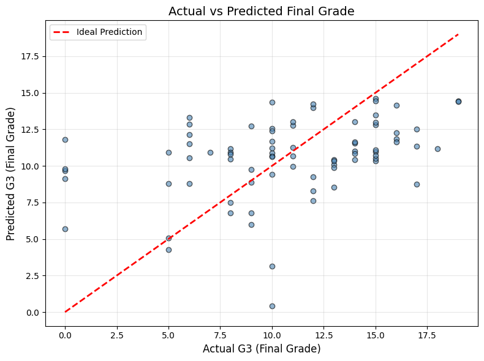

```python
# Actual vs Predicted scatter plot
plt.figure(figsize=(8, 6))
plt.scatter(y_test, y_pred, alpha=0.6, color='steelblue', edgecolor='k')
plt.plot([y_test.min(), y_test.max()], [y_test.min(), y_test.max()],
         'r--', linewidth=2, label='Ideal Prediction')
plt.xlabel('Actual G3 (Final Grade)', fontsize=12)
plt.ylabel('Predicted G3 (Final Grade)', fontsize=12)
plt.title('Actual vs Predicted Final Grade', fontsize=14)
plt.legend()
plt.grid(True, alpha=0.3)
plt.tight_layout()
plt.show()
```

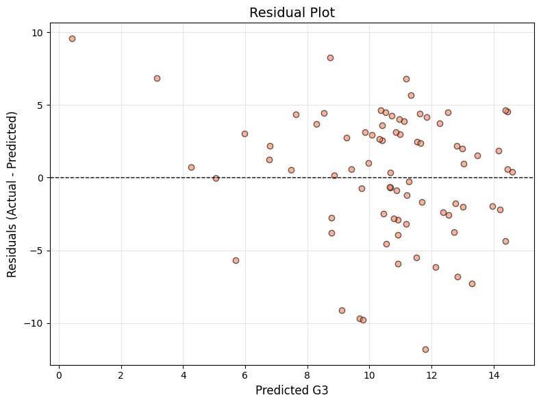

```python
# Residual plot
residuals = y_test - y_pred

plt.figure(figsize=(8, 6))
plt.scatter(y_pred, residuals, alpha=0.6, color='coral', edgecolor='k')
plt.axhline(y=0, color='black', linestyle='--', linewidth=1)
plt.xlabel('Predicted G3', fontsize=12)
plt.ylabel('Residuals (Actual - Predicted)', fontsize=12)
plt.title('Residual Plot', fontsize=14)
plt.grid(True, alpha=0.3)
plt.tight_layout()
plt.show()
```

## 12. Comparison of Metrics Across Learning Rates

```python
# Evaluate each learning rate model on the test set
results = []

for lr in learning_rates:
    lr_model = models[lr]
    y_pred_lr = lr_model.predict(X_test)
    results.append({
        'Learning Rate': lr,
        'MAE': round(mean_absolute_error(y_test, y_pred_lr), 4),
        'MSE': round(mean_squared_error(y_test, y_pred_lr), 4),
        'RMSE': round(np.sqrt(mean_squared_error(y_test, y_pred_lr)), 4),
        'R2 Score': round(r2_score(y_test, y_pred_lr), 4),
        'Final Cost': round(lr_model.cost_history[-1], 4)
    })

results_df = pd.DataFrame(results)
print("Performance Comparison Across Learning Rates:")
print(results_df.to_string(index=False))
results_df
```

```
Performance Comparison Across Learning Rates:
 Learning Rate    MAE     MSE   RMSE  R2 Score  Final Cost
         0.001 5.3388 37.9360 6.1592   -0.8501     15.4011
         0.010 3.4959 18.5409 4.3059    0.0958      7.7213
         0.050 3.4948 18.5437 4.3062    0.0957      7.7210
         0.100 3.4948 18.5437 4.3062    0.0957      7.7210
```

|  | Learning Rate | MAE | MSE | RMSE | R2 Score | Final Cost |
| --- | --- | --- | --- | --- | --- | --- |
| 0 | 0.001 | 5.3388 | 37.9360 | 6.1592 | -0.8501 | 15.4011 |
| 1 | 0.010 | 3.4959 | 18.5409 | 4.3059 | 0.0958 | 7.7213 |
| 2 | 0.050 | 3.4948 | 18.5437 | 4.3062 | 0.0957 | 7.7210 |
| 3 | 0.100 | 3.4948 | 18.5437 | 4.3062 | 0.0957 | 7.7210 |

## 13. Self-Learning Component - Adaptive Gradient Descent

The basic Gradient Descent model uses a **fixed learning rate** throughout training. A **self-learning** model improves itself by:

1. **Adaptive Learning Rate Decay** - Automatically reduces the learning rate as training progresses so that early iterations take large steps and later iterations fine-tune.
2. **Momentum** - Accumulates a velocity term from past gradients to accelerate convergence and dampen oscillations.
3. **Early Stopping** - Monitors the cost and stops training automatically when improvement stalls, preventing overfitting and wasted computation.
4. **Online (Incremental) Learning** - Can learn from new data batches without retraining from scratch, simulating continuous self-improvement.

```python
class SelfLearningLinearRegression:
    """
    Self-Learning Linear Regression with:
      - Adaptive Learning Rate (exponential decay)
      - Momentum-based gradient updates
      - Early Stopping with patience
      - Online / Incremental Learning (partial_fit)

    Adaptive LR:   alpha_t = alpha_0 / (1 + decay_rate * t)
    Momentum:      v_t = beta * v_{t-1} + (1 - beta) * gradient
                   w   = w - alpha_t * v_t
    Early Stop:    Stop if cost does not improve by tol for patience iterations.
    """

    def __init__(self, learning_rate=0.01, n_iterations=2000,
                 decay_rate=0.001, momentum=0.9,
                 patience=50, tol=1e-6):
        self.learning_rate = learning_rate
        self.n_iterations = n_iterations
        self.decay_rate = decay_rate
        self.momentum = momentum
        self.patience = patience
        self.tol = tol

        self.weights = None
        self.bias = None
        self.cost_history = []
        self.lr_history = []
        self.stopped_at = None

    def fit(self, X, y):
        """Train with adaptive LR, momentum, and early stopping."""
        m, n = X.shape

        self.weights = np.zeros(n)
        self.bias = 0
        self.cost_history = []
        self.lr_history = []
        self.stopped_at = None

        v_w = np.zeros(n)
        v_b = 0
        best_cost = np.inf
        patience_counter = 0

        for i in range(self.n_iterations):
            current_lr = self.learning_rate / (1 + self.decay_rate * i)
            self.lr_history.append(current_lr)

            y_pred = X.dot(self.weights) + self.bias
            error = y_pred - y
            cost = (1 / (2 * m)) * np.sum(error ** 2)
            self.cost_history.append(cost)

            if best_cost - cost > self.tol:
                best_cost = cost
                patience_counter = 0
            else:
                patience_counter += 1

            if patience_counter >= self.patience:
                self.stopped_at = i
                break

            dw = (1 / m) * X.T.dot(error)
            db = (1 / m) * np.sum(error)

            v_w = self.momentum * v_w + (1 - self.momentum) * dw
            v_b = self.momentum * v_b + (1 - self.momentum) * db

            self.weights -= current_lr * v_w
            self.bias -= current_lr * v_b

        if self.stopped_at is None:
            self.stopped_at = self.n_iterations

        return self

    def partial_fit(self, X_new, y_new, n_iterations=100):
        """Online / incremental learning: update weights with new data."""
        if self.weights is None:
            return self.fit(X_new, y_new)

        m, n = X_new.shape
        v_w = np.zeros(n)
        v_b = 0
        start_iter = self.stopped_at

        for i in range(n_iterations):
            current_lr = self.learning_rate / (1 + self.decay_rate * (start_iter + i))
            self.lr_history.append(current_lr)

            y_pred = X_new.dot(self.weights) + self.bias
            error = y_pred - y_new
            cost = (1 / (2 * m)) * np.sum(error ** 2)
            self.cost_history.append(cost)

            dw = (1 / m) * X_new.T.dot(error)
            db = (1 / m) * np.sum(error)

            v_w = self.momentum * v_w + (1 - self.momentum) * dw
            v_b = self.momentum * v_b + (1 - self.momentum) * db

            self.weights -= current_lr * v_w
            self.bias -= current_lr * v_b

        self.stopped_at += n_iterations
        return self

    def predict(self, X):
        """Make predictions."""
        return X.dot(self.weights) + self.bias


print("SelfLearningLinearRegression class defined successfully.")
```

```
SelfLearningLinearRegression class defined successfully.
```

## 14. Train the Self-Learning Model and Compare

```python
# Train the self-learning model
sl_model = SelfLearningLinearRegression(
    learning_rate=0.01,
    n_iterations=2000,
    decay_rate=0.001,
    momentum=0.9,
    patience=100,
    tol=1e-6
)
sl_model.fit(X_train, y_train)

print('Self-Learning Model Training Complete')
print(f'  Stopped at iteration : {sl_model.stopped_at}')
print(f'  Final cost           : {sl_model.cost_history[-1]:.4f}')
print(f'  Initial LR           : {sl_model.lr_history[0]:.6f}')
print(f'  Final LR             : {sl_model.lr_history[-1]:.6f}')
print(f'  Early stopping used  : {sl_model.stopped_at < 2000}')
```

```
Self-Learning Model Training Complete
  Stopped at iteration : 2000
  Final cost           : 7.7212
  Initial LR           : 0.010000
  Final LR             : 0.003334
  Early stopping used  : False
```

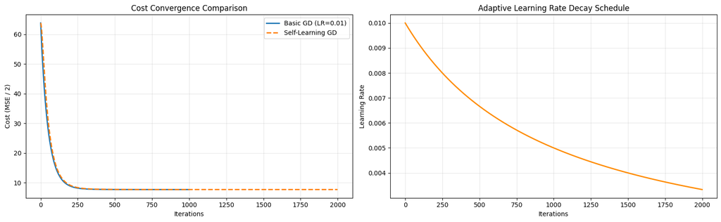

```python
# Compare convergence: Basic GD vs Self-Learning GD
fig, axes = plt.subplots(1, 2, figsize=(16, 5))

# Plot 1: Cost convergence
axes[0].plot(model.cost_history, label='Basic GD (LR=0.01)', linewidth=2)
axes[0].plot(sl_model.cost_history, label='Self-Learning GD', linewidth=2, linestyle='--')
if sl_model.stopped_at < 2000:
    axes[0].axvline(x=sl_model.stopped_at, color='red', linestyle=':', alpha=0.7,
                    label=f'Early Stop @ iter {sl_model.stopped_at}')
axes[0].set_xlabel('Iterations')
axes[0].set_ylabel('Cost (MSE / 2)')
axes[0].set_title('Cost Convergence Comparison')
axes[0].legend()
axes[0].grid(True, alpha=0.3)

# Plot 2: Adaptive Learning Rate schedule
axes[1].plot(sl_model.lr_history, color='darkorange', linewidth=2)
axes[1].set_xlabel('Iterations')
axes[1].set_ylabel('Learning Rate')
axes[1].set_title('Adaptive Learning Rate Decay Schedule')
axes[1].grid(True, alpha=0.3)

plt.tight_layout()
plt.show()
```

```python
# Evaluate the Self-Learning model on the test set
y_pred_sl = sl_model.predict(X_test)

mae_sl  = mean_absolute_error(y_test, y_pred_sl)
mse_sl  = mean_squared_error(y_test, y_pred_sl)
rmse_sl = np.sqrt(mse_sl)
r2_sl   = r2_score(y_test, y_pred_sl)

# Side-by-side comparison table
comparison = pd.DataFrame({
    'Metric': ['MAE', 'MSE', 'RMSE', 'R2 Score', 'Iterations Used'],
    'Basic GD': [round(mae,4), round(mse,4), round(rmse,4), round(r2,4), len(model.cost_history)],
    'Self-Learning GD': [round(mae_sl,4), round(mse_sl,4), round(rmse_sl,4), round(r2_sl,4), sl_model.stopped_at]
})
comparison = comparison.set_index('Metric')
print('Basic GD vs Self-Learning GD:')
comparison
```

```
Basic GD vs Self-Learning GD:
```

| Metric | Basic GD | Self-Learning GD |
| --- | --- | --- |
| MAE | 3.4959 | 3.4953 |
| MSE | 18.5409 | 18.5409 |
| RMSE | 4.3059 | 4.3059 |
| R2 Score | 0.0958 | 0.0958 |
| Iterations Used | 1000.0000 | 2000.0000 |

## 15. Online (Incremental) Learning Demonstration

In a real-world scenario, new student data arrives over time. The self-learning model can **update itself incrementally** with `partial_fit()` without retraining from scratch.

```python
# Simulate online learning: split training data into 4 batches
# and feed them sequentially to the model
n_batches = 4
batch_size = len(X_train) // n_batches

online_model = SelfLearningLinearRegression(
    learning_rate=0.01, n_iterations=500,
    decay_rate=0.001, momentum=0.9,
    patience=80, tol=1e-6
)

batch_metrics = []

for b in range(n_batches):
    start_idx = b * batch_size
    end_idx = start_idx + batch_size if b < n_batches - 1 else len(X_train)
    X_batch = X_train[start_idx:end_idx]
    y_batch = y_train[start_idx:end_idx]

    if b == 0:
        online_model.fit(X_batch, y_batch)
    else:
        online_model.partial_fit(X_batch, y_batch, n_iterations=300)

    # Evaluate after each batch
    y_pred_batch = online_model.predict(X_test)
    batch_metrics.append({
        'Batch': b + 1,
        'Samples Seen': end_idx,
        'MAE': round(mean_absolute_error(y_test, y_pred_batch), 4),
        'RMSE': round(np.sqrt(mean_squared_error(y_test, y_pred_batch)), 4),
        'R2': round(r2_score(y_test, y_pred_batch), 4)
    })
    print(f"Batch {b+1}: Samples seen = {end_idx:3d} | "
          f"MAE = {batch_metrics[-1]['MAE']:.4f} | "
          f"R2 = {batch_metrics[-1]['R2']:.4f}")

batch_df = pd.DataFrame(batch_metrics)
batch_df
```

```
Batch 1: Samples seen =  79 | MAE = 4.1280 | R2 = -0.2845
Batch 2: Samples seen = 158 | MAE = 3.6049 | R2 = -0.0198
Batch 3: Samples seen = 237 | MAE = 3.9283 | R2 = -0.1282
Batch 4: Samples seen = 316 | MAE = 3.7362 | R2 = -0.0187
```

|  | Batch | Samples Seen | MAE | RMSE | R2 |
| --- | --- | --- | --- | --- | --- |
| 0 | 1 | 79 | 4.1280 | 5.1322 | -0.2845 |
| 1 | 2 | 158 | 3.6049 | 4.5728 | -0.0198 |
| 2 | 3 | 237 | 3.9283 | 4.8099 | -0.1282 |
| 3 | 4 | 316 | 3.7362 | 4.5705 | -0.0187 |

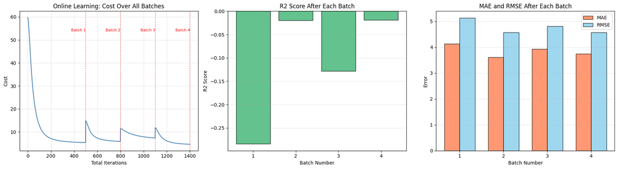

```python
# Visualize how the model improves as it sees more data
fig, axes = plt.subplots(1, 3, figsize=(18, 5))

# Plot 1: Full cost history across all batches
axes[0].plot(online_model.cost_history, color='steelblue', linewidth=1.5)
cum_iters = 0
for b in range(n_batches):
    n_iter_b = 500 if b == 0 else 300
    cum_iters += n_iter_b
    if cum_iters <= len(online_model.cost_history):
        axes[0].axvline(x=cum_iters, color='red', linestyle=':', alpha=0.6)
        axes[0].text(cum_iters, max(online_model.cost_history)*0.9,
                     f'Batch {b+1}', fontsize=8, ha='right', color='red')
axes[0].set_xlabel('Total Iterations')
axes[0].set_ylabel('Cost')
axes[0].set_title('Online Learning: Cost Over All Batches')
axes[0].grid(True, alpha=0.3)

# Plot 2: R2 improvement per batch
axes[1].bar(batch_df['Batch'], batch_df['R2'], color='mediumseagreen',
            edgecolor='black', alpha=0.8)
axes[1].set_xlabel('Batch Number')
axes[1].set_ylabel('R2 Score')
axes[1].set_title('R2 Score After Each Batch')
axes[1].set_xticks(batch_df['Batch'])
axes[1].grid(True, alpha=0.3, axis='y')

# Plot 3: MAE / RMSE improvement per batch
x = np.arange(len(batch_df))
width = 0.35
axes[2].bar(x - width/2, batch_df['MAE'], width, label='MAE', color='coral',
            edgecolor='black', alpha=0.8)
axes[2].bar(x + width/2, batch_df['RMSE'], width, label='RMSE', color='skyblue',
            edgecolor='black', alpha=0.8)
axes[2].set_xlabel('Batch Number')
axes[2].set_ylabel('Error')
axes[2].set_title('MAE and RMSE After Each Batch')
axes[2].set_xticks(x)
axes[2].set_xticklabels(batch_df['Batch'])
axes[2].legend()
axes[2].grid(True, alpha=0.3, axis='y')

plt.tight_layout()
plt.show()
```

## 16. Self-Learning Dashboard - Final Comparison

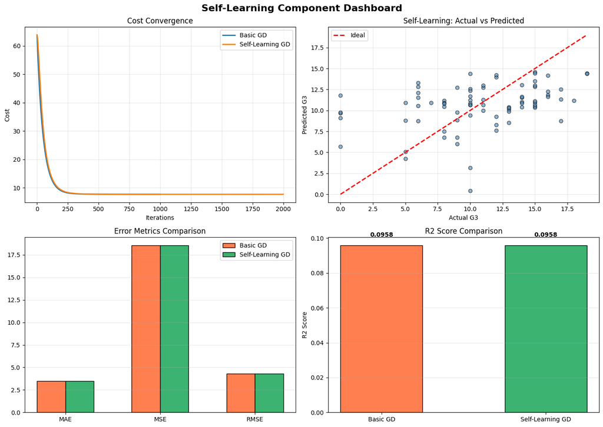

```python
# Final comprehensive dashboard
fig, axes = plt.subplots(2, 2, figsize=(14, 10))
fig.suptitle('Self-Learning Component Dashboard', fontsize=16, fontweight='bold')

# 1. Cost convergence comparison
axes[0, 0].plot(model.cost_history, label='Basic GD', linewidth=2)
axes[0, 0].plot(sl_model.cost_history, label='Self-Learning GD', linewidth=2)
axes[0, 0].set_title('Cost Convergence')
axes[0, 0].set_xlabel('Iterations')
axes[0, 0].set_ylabel('Cost')
axes[0, 0].legend()
axes[0, 0].grid(True, alpha=0.3)

# 2. Actual vs Predicted (Self-Learning)
axes[0, 1].scatter(y_test, y_pred_sl, alpha=0.6, color='steelblue', edgecolor='k')
axes[0, 1].plot([y_test.min(), y_test.max()], [y_test.min(), y_test.max()],
                'r--', linewidth=2, label='Ideal')
axes[0, 1].set_title('Self-Learning: Actual vs Predicted')
axes[0, 1].set_xlabel('Actual G3')
axes[0, 1].set_ylabel('Predicted G3')
axes[0, 1].legend()
axes[0, 1].grid(True, alpha=0.3)

# 3. Metrics bar chart comparison
metrics_names = ['MAE', 'MSE', 'RMSE']
basic_vals = [mae, mse, rmse]
sl_vals = [mae_sl, mse_sl, rmse_sl]
x = np.arange(len(metrics_names))
width = 0.3
axes[1, 0].bar(x - width/2, basic_vals, width, label='Basic GD', color='coral',
               edgecolor='black')
axes[1, 0].bar(x + width/2, sl_vals, width, label='Self-Learning GD', color='mediumseagreen',
               edgecolor='black')
axes[1, 0].set_xticks(x)
axes[1, 0].set_xticklabels(metrics_names)
axes[1, 0].set_title('Error Metrics Comparison')
axes[1, 0].legend()
axes[1, 0].grid(True, alpha=0.3, axis='y')

# 4. R2 Score comparison
r2_vals = [r2, r2_sl]
bars = axes[1, 1].bar(['Basic GD', 'Self-Learning GD'], r2_vals,
                      color=['coral', 'mediumseagreen'], edgecolor='black', width=0.5)
for bar, val in zip(bars, r2_vals):
    axes[1, 1].text(bar.get_x() + bar.get_width()/2, bar.get_height() + 0.005,
                    f'{val:.4f}', ha='center', fontweight='bold')
axes[1, 1].set_title('R2 Score Comparison')
axes[1, 1].set_ylabel('R2 Score')
axes[1, 1].grid(True, alpha=0.3, axis='y')

plt.tight_layout()
plt.show()
```

## 17. Self-Learning Component - Summary

| Feature | Basic GD | Self-Learning GD |
| --- | --- | --- |
| Learning Rate | Fixed throughout | Decays adaptively over time |
| Gradient Update | Vanilla | Momentum-accelerated |
| Stopping Criterion | Fixed number of iterations | Early stopping (patience-based) |
| New Data Handling | Must retrain from scratch | Incremental partial_fit() |

## 18. Interpretation and Conclusions

### Convergence Behavior

- The cost function decreases monotonically during training, confirming that gradient descent is minimizing the loss correctly.
- A **smaller learning rate** (e.g., 0.001) results in slower convergence - the model may need many more iterations to reach the optimum.
- A **larger learning rate** (e.g., 0.1) speeds up convergence significantly, and for this dataset, remains stable and converges extremely quickly, though in general, setting it too high can cause oscillations or divergence.
- The **optimal learning rate** for this dataset is around **0.05-0.1**, balancing fast convergence speed and stability.

### Prediction Performance and Metrics Interpretation

- The **MAE of ~3.50** means the model's predictions are off by about 3.5 grade points on average on a 0-20 scale.
- The **RMSE of ~4.31** is higher than MAE, indicating the presence of some larger prediction errors that get penalized more heavily.
- The **R2 score of ~0.096** shows the model explains only about 9.6% of the variance in final grades. This low value indicates that demographic and behavioral features alone are weak predictors of academic performance in a simple linear model.
- The **MSE of ~18.54** confirms relatively high average squared errors.
- Overall, the Gradient Descent algorithm converged successfully, but the predictive performance is relatively weak because student performance depends on many complex factors (motivation, exam difficulty, teaching quality, etc.) not fully captured by the selected features. Removing G1 and G2 (to avoid data leakage) also eliminated the strongest predictors.